# Part II - (Exploration the Ford GoBike System Dataset)

## Dataset Overview

> Ford GoBike is a bike-sharing system in the San Francisco Bay Area, operated by Motivate International. The system allows users to rent bicycles for short trips, using a network of automated kiosks and mobile app. Users can purchase a membership or pay for each ride individually. The system provides data on bike availability, usage, and trip information to the public, which can be used for transportation planning, research, and other purposes.

```python
# import all packages and set plots to be embedded inline
import numpy as np
import pandas as pd
import matplotlib.pyplot as plt
import seaborn as sns

%matplotlib inline

# suppress warnings from final output
import warnings
warnings.simplefilter("ignore")
```

```python
# load in the dataset into a pandas dataframe
df=pd.read_csv("201902-fordgobike-tripdata-clean.csv")
```

> Note that the above cells have been set as "Skip"-type slides. That means that when the notebook is rendered as http slides, those cells won't show up.

## (Visualization 1)

> The plot shows the most of users are subscribers

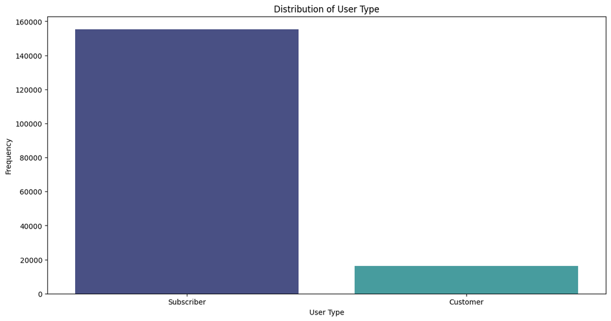

```python
plt.figure(figsize=[14,7])
fig=sns.barplot(x=df['user_type'].value_counts().index,y=df['user_type'].value_counts(),palette='mako')
fig.set(ylabel='Frequency',xlabel='User Type',title='Distribution of User Type');
```

## (Visualization 2)

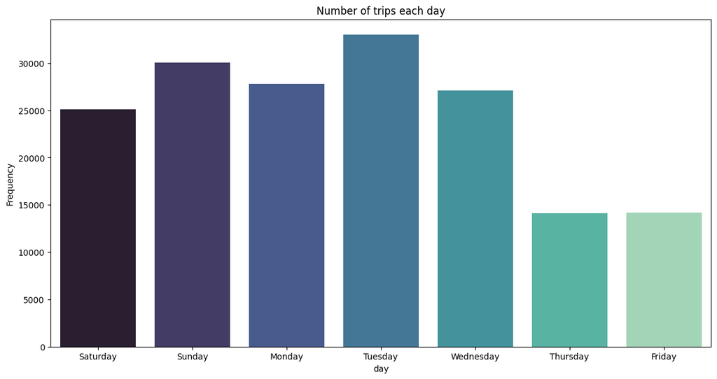

```python
plt.figure(figsize=[14,7])

fig = sns.barplot(x=df['days_ordered'].value_counts().index, y= df['day'].value_counts(),palette='mako')
fig.set(xlabel='day', ylabel='Frequency',title='Number of trips each day' );
```

## (Visualization 3)

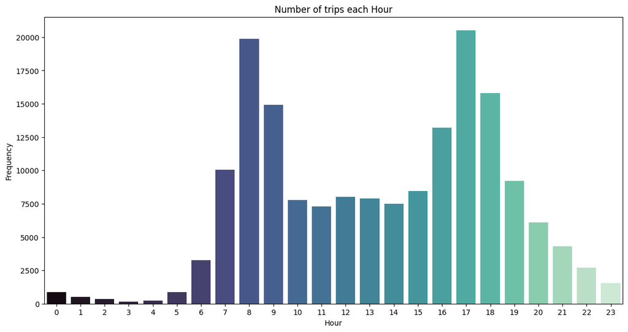

```python
plt.figure(figsize=[14,7])
fig = sns.barplot(x=df['hour'].value_counts().index, y= df['hour'].value_counts(),palette='mako')
fig.set(xlabel='Hour', ylabel='Frequency',title='Number of trips each Hour' );
```

### Generate Slideshow

Once you're ready to generate your slideshow, use the `jupyter nbconvert` command to generate the HTML slide show.

```python
# Use this command if you are running this file in local
!jupyter nbconvert Part_II_slide_deck_template.ipynb --to slides --post serve --no-input --no-prompt
```

> In the classroom workspace, the generated HTML slideshow will be placed in the home folder.

> In local machines, the command above should open a tab in your web browser where you can scroll through your presentation. Sub-slides can be accessed by pressing 'down' when viewing its parent slide. Make sure you remove all of the quote-formatted guide notes like this one before you finish your presentation! At last, you can stop the Kernel.